# Prosper Loan Exploration by Michael Phillips

> This report explores a dataset containing approximately 110,000 loans issued by Prosper. Prosper describes itself as America’s first “marketplace lending platform”, where a person posts the amount of money they are seeking, and a private investor can then fund the loan (expecting a return with interest) if they choose.

## Univariate Plots

```
## [1] 113937     23
```

```
## 'data.frame':    113937 obs. of  23 variables:
##  $ X                          : int  1 2 3 4 5 6 7 8 9 10 ...
##  $ ListingNumber              : int  193129 1209647 81716 658116 909464 1074836 750899 768193 1023355 1023355 ...
##  $ ListingCreationDate        : Factor w/ 113064 levels "2005-11-09 20:44:28.847000000",..: 14184 111894 6429 64760 85967 100310 72556 74019 97834 97834 ...
##  $ CreditGrade                : Factor w/ 9 levels "","A","AA","B",..: 5 1 8 1 1 1 1 1 1 1 ...
##  $ ProsperRating..Alpha.      : Factor w/ 8 levels "","A","AA","B",..: 1 2 1 2 6 4 7 5 3 3 ...
##  $ Term                       : int  36 36 36 36 36 60 36 36 36 36 ...
##  $ LoanStatus                 : Factor w/ 12 levels "Cancelled","Chargedoff",..: 3 4 3 4 4 4 4 4 4 4 ...
##  $ ClosedDate                 : Factor w/ 2803 levels "","2005-11-25 00:00:00",..: 1138 1 1263 1 1 1 1 1 1 1 ...
##  $ BorrowerAPR                : num  0.165 0.12 0.283 0.125 0.246 ...
##  $ BorrowerRate               : num  0.158 0.092 0.275 0.0974 0.2085 ...
##  $ LenderYield                : num  0.138 0.082 0.24 0.0874 0.1985 ...
##  $ ProsperScore               : int  NA 7 NA 9 4 10 2 4 9 11 ...
##  $ Occupation                 : Factor w/ 68 levels "","Accountant/CPA",..: 37 43 37 52 21 43 50 29 24 24 ...
##  $ EmploymentStatus           : Factor w/ 9 levels "","Employed",..: 9 2 4 2 2 2 2 2 2 2 ...
##  $ CreditScoreRangeLower      : int  640 680 480 800 680 740 680 700 820 820 ...
##  $ CreditScoreRangeUpper      : int  659 699 499 819 699 759 699 719 839 839 ...
##  $ OpenRevolvingMonthlyPayment: int  24 389 0 115 220 1410 214 101 219 219 ...
##  $ BankcardUtilization        : num  0 0.21 NA 0.04 0.81 0.39 0.72 0.13 0.11 0.11 ...
##  $ AvailableBankcardCredit    : int  1500 10266 NA 30754 695 86509 1929 2181 77696 77696 ...
##  $ IncomeRange                : Factor w/ 8 levels "$0","$1-24,999",..: 4 5 7 4 3 3 4 4 4 4 ...
##  $ DebtToIncomeRatio          : num  0.17 0.18 0.06 0.15 0.26 0.36 0.27 0.24 0.25 0.25 ...
##  $ StatedMonthlyIncome        : num  3083 6125 2083 2875 9583 ...
##  $ IncomeVerifiable           : Factor w/ 2 levels "False","True": 2 2 2 2 2 2 2 2 2 2 ...
```

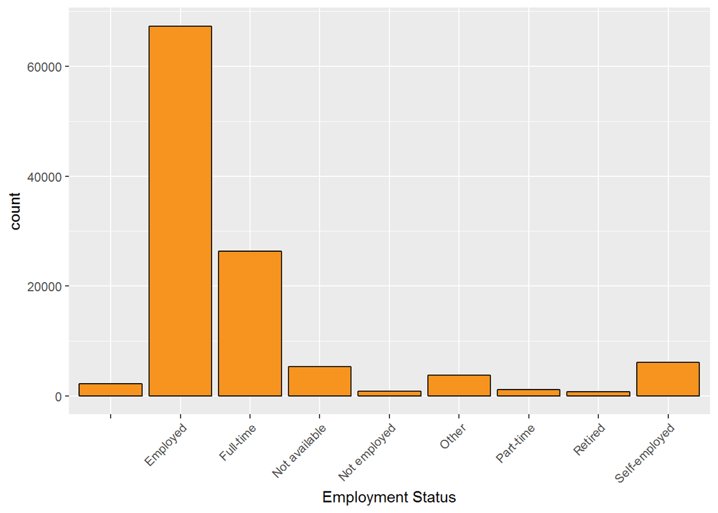

> As expected, most people are employed. It is surprising some people received loans by not listing any employment status.

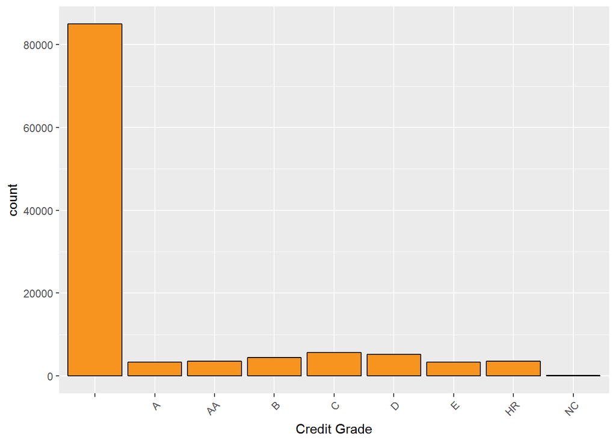

> As soon as I saw this histogram I had to find a reason why more than 80,000 loans were not given a credit grade - the Variable Definitions explain that only listings from pre-2009 were given a Credit Grade.

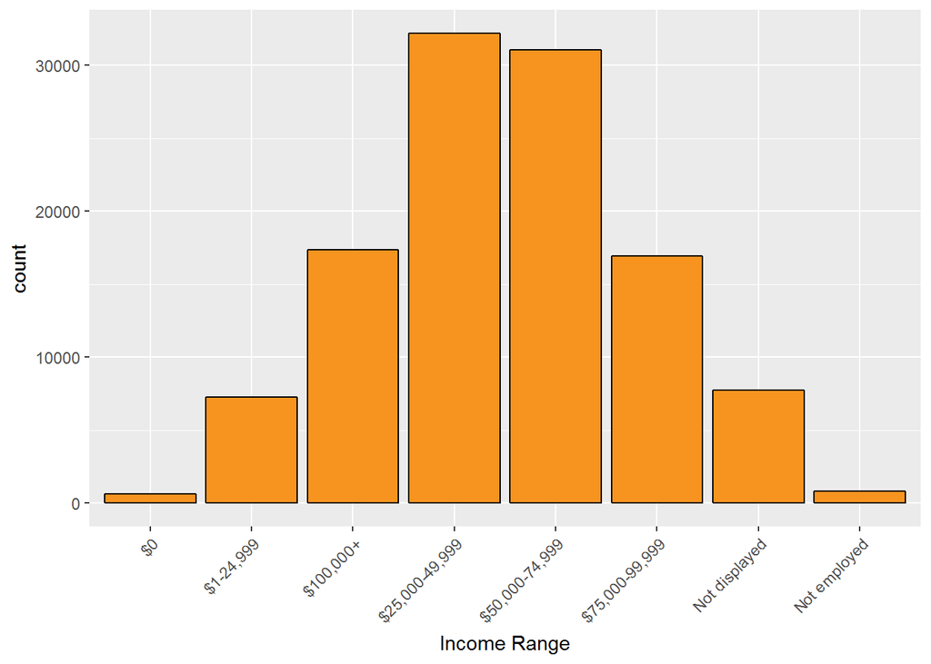

> This chart shows a concentration around $50,000, which is very close to the median household income estimated by the Federal Reserve for 2015. For a bit more detail, lets look at some descriptive statistics for the variable, “StatedMonthlyIncome”.

```
##    Min. 1st Qu.  Median    Mean 3rd Qu.    Max.
##       0    3200    4667    5608    6825 1750000
```

> Wow! Someone apparently has a monthly income of almost 2 million dollars and is asking for a loan. Let’s look at that entry from the dataframe.

```
##       ListingNumber EmploymentStatus StatedMonthlyIncome
## 53168        560783    Self-employed             1750003
```

> He or she states that they are self-employed. I suppose its not impossible for this obvious outlier to be a valid entry. Are there any other data points above $500,000?

```r
#find the number of rows in my query
sum(loan_df_subset$StatedMonthlyIncome > 500000)
```

```
## [1] 2
```

> I want to take a look at the listing for the other point as well.

```
##       ListingNumber EmploymentStatus StatedMonthlyIncome
## 53015        694401    Self-employed            618547.8
```

> The other person is also self-employed. Interesting, again, not totally unreasonable.

> Next, I want to look at the credit scores of the loan applicants.

```
##    Min. 1st Qu.  Median    Mean 3rd Qu.    Max.    NA's
##     9.5   669.5   689.5   695.1   729.5   889.5     591
```

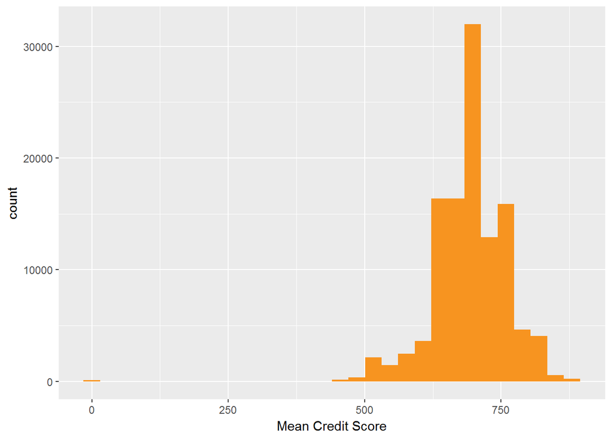

> Most of the Credit Scores are between 425 and 875. Lets zoom in on that region.

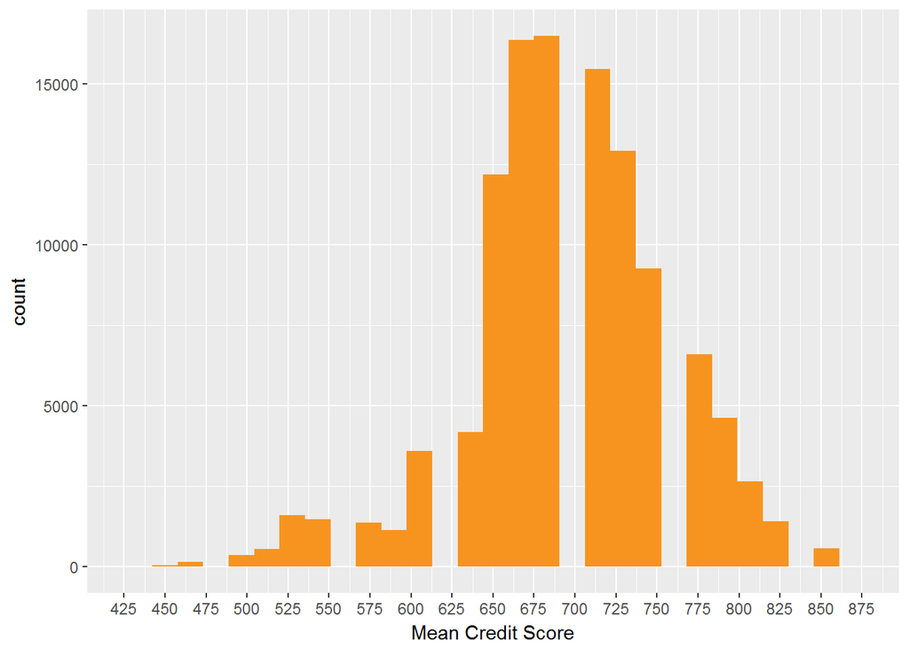

> We can see the negative skew of this graph, with most people falling within the same ‘bucket’ of credit scores. I’m curious how many exactly are under 425.

```
## [1] 134
```

> Out of 113,937 possible loans, only 134 fall under a 425 Credit Score.

> I also want to get a sense of the variance between the lending rates described in the dataset.

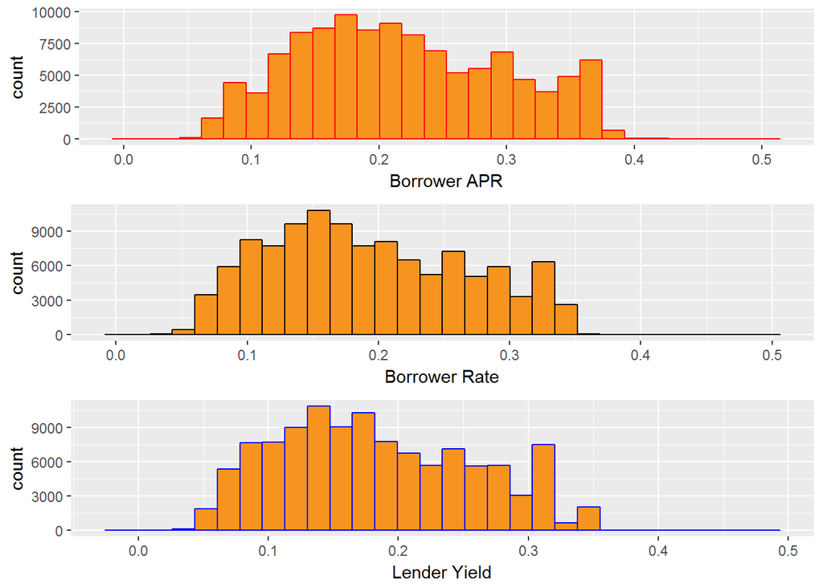

> Borrower APR is the rate on the total amount of money an applicant owes, Borrower Rate is the rate only on the principle money (not including fees owed to Prosper), and the Lender Yield is the return rate the person lending the money can expect. Overall, the spread of interest rates is a little more uniform than I had expected.

## Univariate Analysis

### What is/are the main feature(s) of interest in the dataset?

> The main feature of interest to me is the relationship between variables such as income or credit score and the eventual credit rate the applicant received. Some of these factors are credit score, employment, occupation, and income range/monthly income.

### What other features in the dataset do you think will help support your investigation into your feature(s) of interest?

> There are some variables that have not been examined yet that I am curious about. Variables such as credit card available balance, percentage of credit card utilization, and whether or not a person’s stated income being verifiable or not had any impact on loan rates.

### Did you create any new variables from existing variables in the dataset?

> Yes, I created the mean credit score variable from upper and lower bound credit scores to have one summary statistic for the range. I also did some transformation on the whole dataset after examining the variable dictionary, narrowing it down to only the variables that interested me.

### Of the features you investigated, were there any unusual distributions? Did you perform any operations on the data to tidy, adjust, or change the form of the data?

> I was surprised by a few things while examing the data, particularly how a majority of applicants were not given a credit rating, and the outliers amongst the positive end of the monthly income graph. Both irregularities were eventually explained to the point that no further investigation, or cleaning of data, was required.

> I did perform some quick data manipulations to look at specific rows, and to add a new variable. I also used subsets in several instances to narrow the focus down to specific points of interest.

## Bivariate Plots

```
##                         BorrowerAPR BankcardUtilization
## BorrowerAPR                    1.00                0.28
## BankcardUtilization            0.28                1.00
## AvailableBankcardCredit       -0.36               -0.36
## DebtToIncomeRatio              0.06                0.04
## meanCreditScore               -0.51               -0.40
## StatedMonthlyIncome           -0.13                0.05
##                         AvailableBankcardCredit DebtToIncomeRatio
## BorrowerAPR                               -0.36              0.06
## BankcardUtilization                       -0.36              0.04
## AvailableBankcardCredit                    1.00              0.00
## DebtToIncomeRatio                          0.00              1.00
## meanCreditScore                            0.46             -0.02
## StatedMonthlyIncome                        0.17             -0.13
##                         meanCreditScore StatedMonthlyIncome
## BorrowerAPR                       -0.51               -0.13
## BankcardUtilization               -0.40                0.05
## AvailableBankcardCredit            0.46                0.17
## DebtToIncomeRatio                 -0.02               -0.13
## meanCreditScore                    1.00                0.15
## StatedMonthlyIncome                0.15                1.00
```

> My main point of interest is which factors have the greatest impact on Borrower APR. I chose Borrower APR has my main indicator of loan rate because it is a more realistic indicator of the loan rate than Borrower Rate (which does not include fees passed along by the lending institution) or Lender Yield, which is a measure of the return a lender can reasonably expect. The correlations above show that out of the listed variables, Mean Credit Score is most closely correlated with APR, with the other variables coming in at somewhat lower correlations.

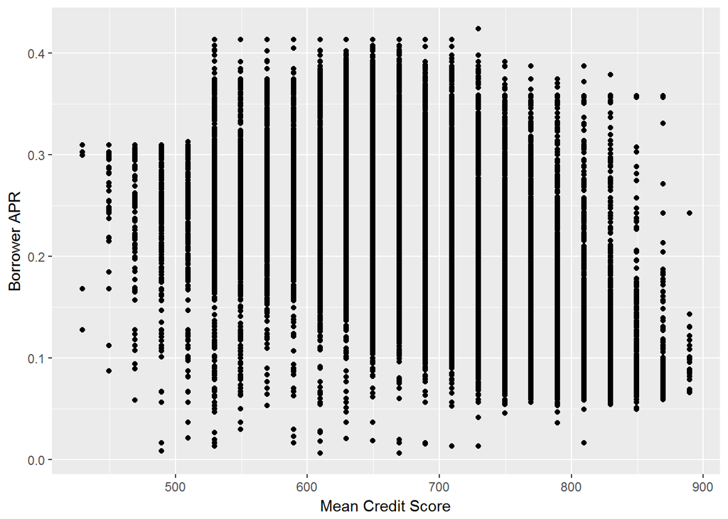

> It looks like the credit scores are falling in buckets of values, and it is hard to discern a trend here. I will introduce alpha, jitter, and a line of best fit to hopefully see more of the story.

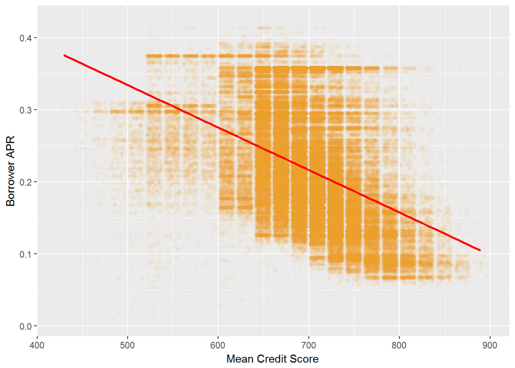

> From this adjusted plot we can see a fairly concrete visualization of the downward trend between Mean Credit Score and Borrower APR. The red line represents the line of best fit for the scatterplot. An alpha of .04 was used to see where the points are concentrated, and jitter was added to introduce some noise to the data.

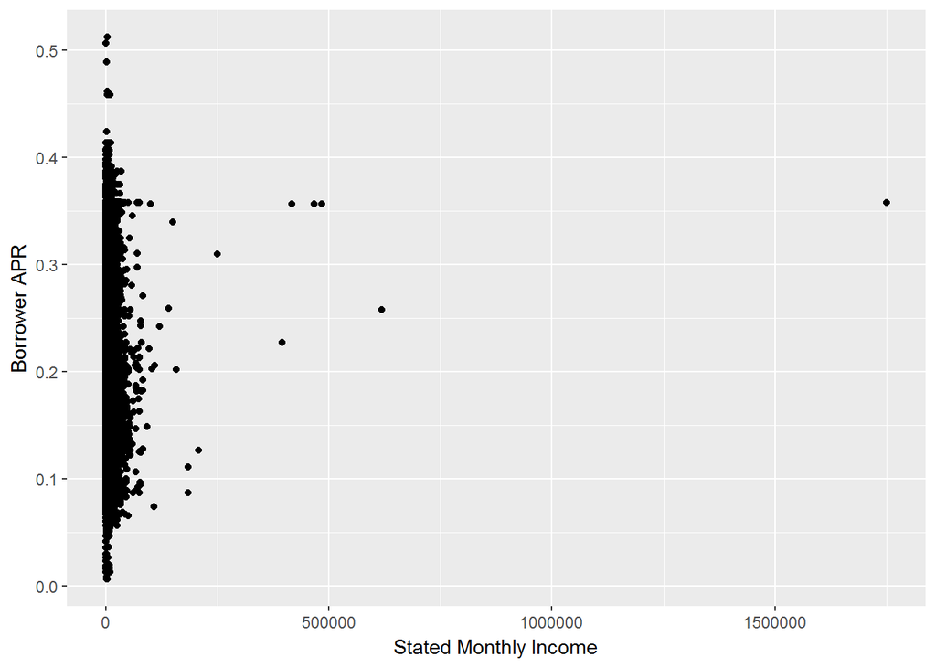

> Next I want to look at Stated Monthly Income vs. Borrower APR. The above first go was not what I had in mind. Those outliers are skewing the plot. I suspect most of the applicants had a monthly income of under $10,000. First, I want to check that this is the case.

```r
nrow(subset(loan_df_subset, StatedMonthlyIncome <= 10000))
```

```
## [1] 104157
```

> Out of 113,937 total rows, 104,157 have a monthly income under or equal to $10,000. Lets use that subset to try the scatter plot again.

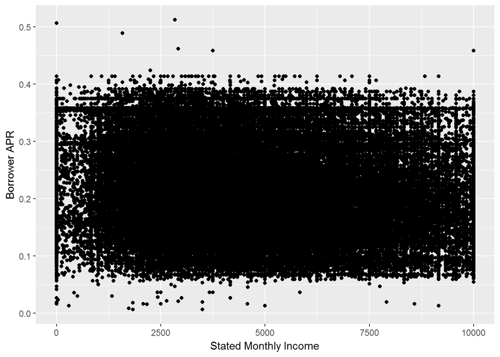

> This is a little better, but suffers from overplotting. Lets introduce an alpha to try to see a trend.

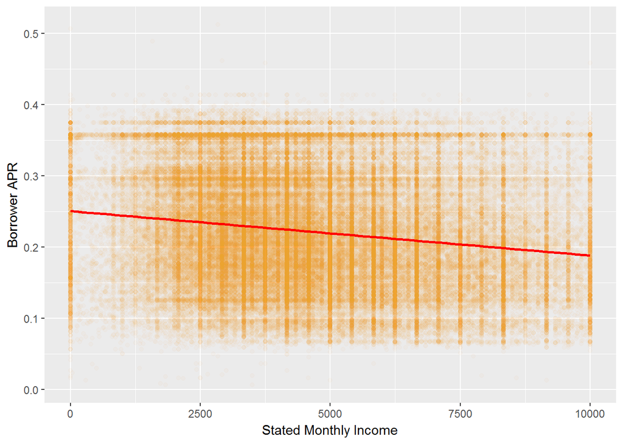

> This plot shows clearly demarcated vertical lines at certain monthly incomes. This is likely due to the fact that loan applicants enter this amount with no clear validation, and some rounding of the figure is expected. A person might make $2,800 and round up to $3,000 for example.

> We can see that the slope of the line of best fit is not as steep as from the previous graph of mean credit rating vs. Borrower APR. This aligns with the correlations at the top of the section which show that mean credit rating is more closely correlated with Borrower APR than Monthly Income is.

> The scatterplot is very noisy and while a trend is visible, it is not very clear. I think I will try a smoothed line graph to see the results more distinctly.

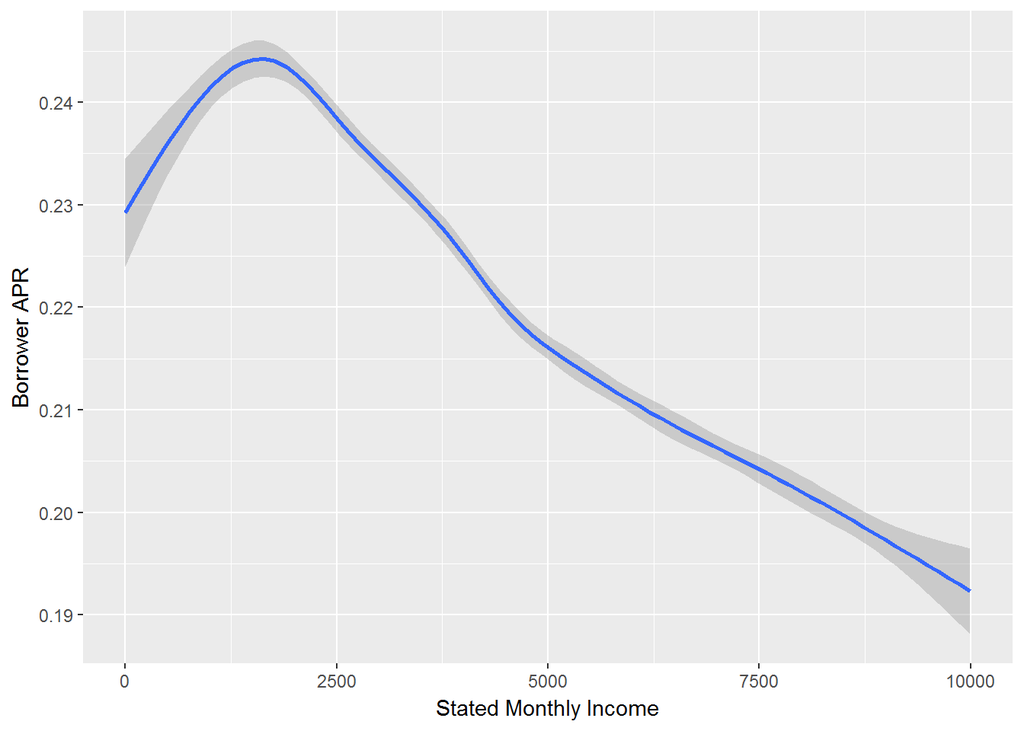

> That is much more clear. Some detail is lost in the process of smoothing, but the trend is now unobscured by the noisy data. As Monthly Income goes up, the Borrower APR goes down.

> For the next plot I want to look at Prosper Rating (alpha) vs. Borrower APR. Prosper Rating is a ranking of the risk associated with a borrower. ‘AA’ is the ranking for the lowest risk, while ‘HR’ represents the highest risk. This rating was only implemented after 2009. For the purposes of this exploration, I am okay with this limitation. I am more interested in the recent trends than ones dating back to the start of the dataset, which happens to be more than a decade. For the purposes of the below plot, I will omit ‘NA’ values.

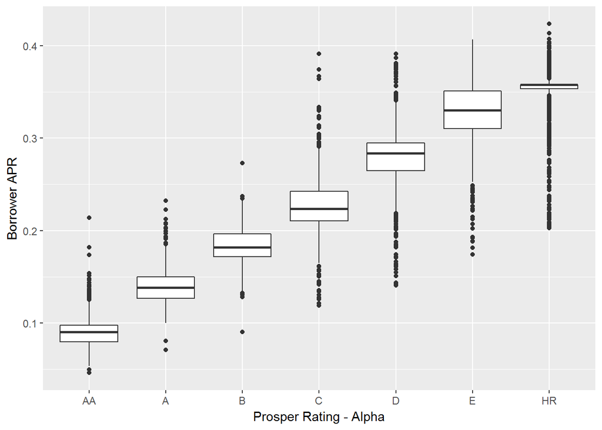

> From the above box plot we can see that median Borrower APR goes down as the Prosper Rating measuring loan risk also goes down. There are some outliers amongst the data as would be expected. The Prosper Rating is not the only factor that goes in to assigning an APR, but it does show a relationship between the rating and eventual APR as a general rule.

> Next, I want to take a look at the summary statistics for the Prosper Rating.

```r
tapply(loan_df_subset$BorrowerAPR, loan_df_subset$ProsperRating..Alpha.,
       summary)
```

[output not shown]

> The general trend visible in the box plot is also visible here, with the mean borrower APR trending downward as the credit rating gets better (less risky).

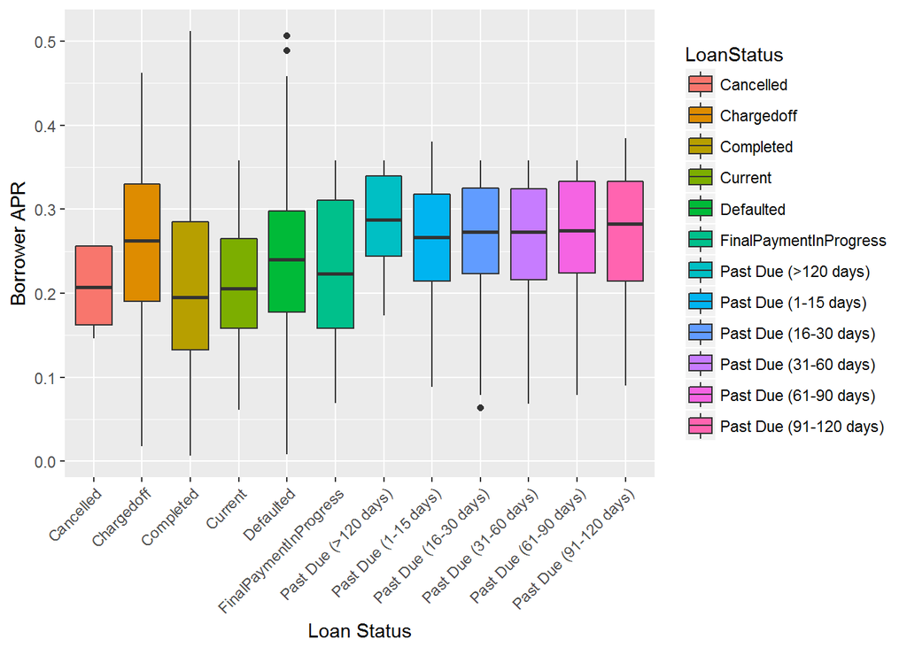

> This box plot is another way to look at correlations to Borrower APR. The loan status describes the state of the loan. It appears that the assigned APR was slightly higher overall for loans whose payments are past due compared to loans that are paid off or otherwise current.

## Bivariate Analysis

### What are some of the relationships you observed in this part of the investigation?

> I looked at how different variables related to Borrower APR. I saw clear indications of trends using both a correlation table, and plots. The most highly correlated variable with Borrower APR was Mean Credit Score, this makes sense because it is the most complete picture of a person’s credit history, and in some cases includes other variables when calculating the score (such as credit card history). I also looked at other factors including Loan Status and Prosper Rating to see if these factors had any relationship to Borrower APR.

### Did you observe any interesting relationships between the other features of the dataset?

> I was not originally going to explore the Loan Status or Prosper Rating variables, but then I had a thought that maybe they could be used to predict either credit risk or (for a person requesting a loan) their eventual assigned APR. I think that this would be a valid exploration, particularly for Prosper Rating as that relationship appeared quite strong.

### What was the strongest relationship you found?

> The strongest relationship that I found was between Mean Credit Score and Borrower APR. As mentioned in the previous question, I think this relationship would be a decent starting point for a borrower or lender to examine the rates offered and to see if they are in line with previous loans issued through Prosper, and also could be used to estimate what rate they might eventually receive.

## Multivariate Plots

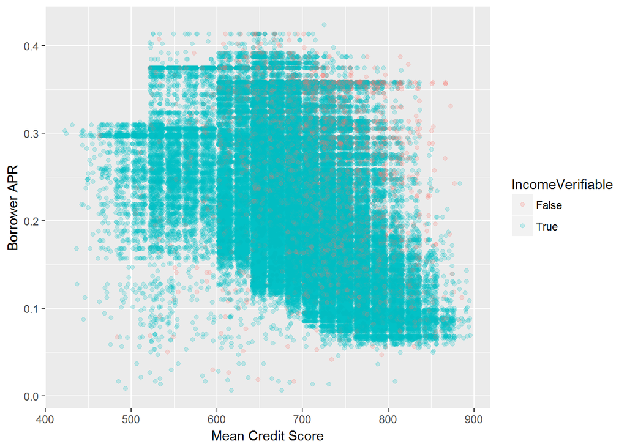

> This result is interesting. It appears that applicants with unverified income received higher interest rates. I am going to take a slight detour and look at summary statistics for each factor of Income Verifiable.

```r
#create a new dataframe holding only the variables of interest
income_df <- loan_df_subset %>%
    select(ListingNumber, BorrowerAPR, IncomeVerifiable)

#create new dataframes to run the summary off of
income_df_true <- subset(income_df, IncomeVerifiable == 'True')
income_df_false <- subset(income_df, IncomeVerifiable == 'False')

#run the summary for 'false' values
tapply(income_df_false$BorrowerAPR,
       income_df_false$IncomeVerifiable, summary)
```

```
## $False
##    Min. 1st Qu.  Median    Mean 3rd Qu.    Max.
## 0.01657 0.17970 0.25010 0.24960 0.32540 0.50630
##
## $True
## NULL
```

```r
#run the summary for 'true' values
tapply(income_df_true$BorrowerAPR,
       income_df_true$IncomeVerifiable, summary)
```

```
## $False
## NULL
##
## $True
##    Min. 1st Qu.  Median    Mean 3rd Qu.    Max.    NA's
## 0.00653 0.15430 0.20700 0.21630 0.27710 0.51230      25
```

> The inferences made from the scatterplot were supported by descriptive statistics. The mean and median Borrower APR for applicants who could not have their income verified was higher than for applicants who did have their income verified.

> Next, lets look at the mean credit score vs. Borrower APR, with colors highlighting a variable not yet examined - Occupation. There are 68 different occupations in the dataset so first I’ll subset it down to the ones I am most interested in.

```r
#create a new dataframe holding only the variables of interest
occupation_df <- loan_df_subset %>%
    select(ListingNumber,
           ProsperRating..Alpha.,
           BorrowerAPR,
           Occupation,
           meanCreditScore)

#subset the dataframe to only the occupations of interest
occupation_df <- subset(occupation_df, (Occupation == 'Accountant/CPA' |
                                        Occupation =='Waiter/Waitress' |
                                        Occupation =='Teacher'))
```

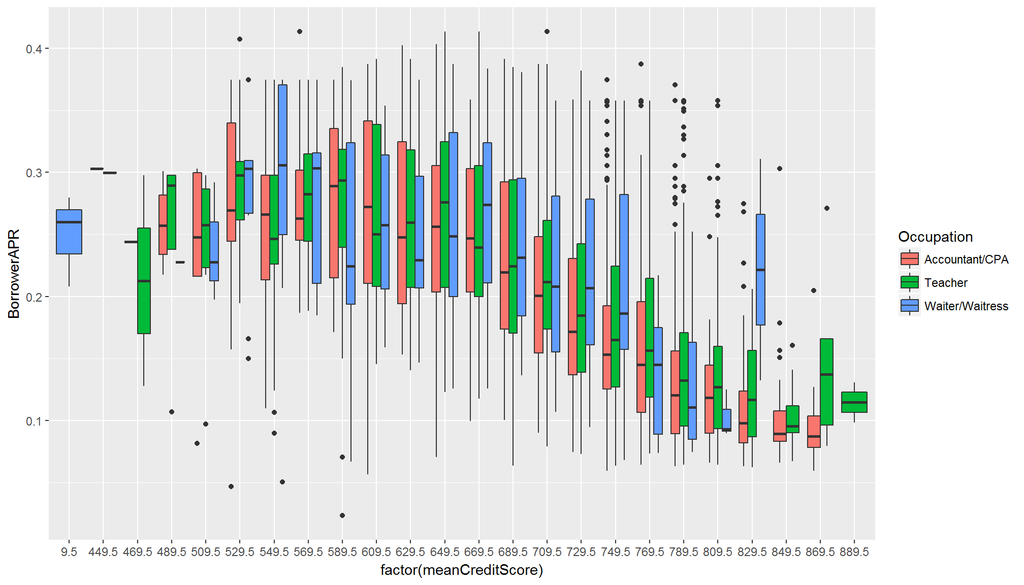

> Wow, that is not really at all what I expected. The general trend seen in the whole dataset of APR going down as credit score goes up continues here, what was unexpected was the mostly uniform distribution for each occupation in the plot. There are people of every profession spread throughout the credit score range. In a broad sense this is intuitive, just because a person is an accountant doesn’t mean they necessarily have a good credit score. I was expecting a bit more of a separation between the occupations, I guess based on my own preconceptions of each labor group. Lets use the occupations again to look at the Prosper Ratings given to each group.

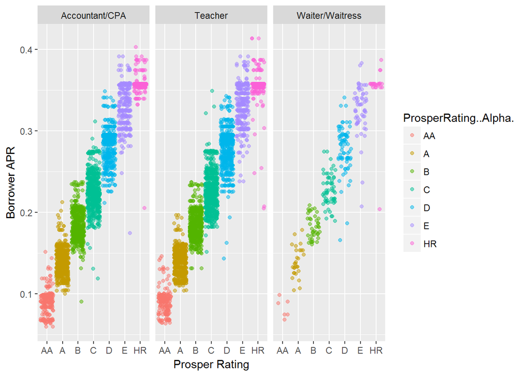

> In this plot we can see comparitively less ‘AA’ ratings, which represent the least risk loans, given to Waiters or Waitresses compared to Accountants and Teachers. We can also see each of the occupations contains outliers in the higher risk ratings as was indicated by the previous plot. The general distribution of ratings is otherwise very, very similar.

## MultiVariate Analysis

### What were some of the relationships observed in this part of the investigation?

> I looked at the Income Verifiable variable from the dataset and examined if it had any effect on APR overall. From my investigation, it did have an overall higher mean APR when income was not verified versus when it could be. This mostly fell in line with my expectations. More interesting to me as it was not at all what I expected was the Occupation plots that measured credit score, and Prosper Rating vs. Borrower APR. I think I let my prior preconceptions color my views here, and in fact hadn’t used the Occupation variable at all through this investigation as I thought I knew what results it would show. The actual data and plots were much more uniform than I had anticipated.

## Final Plots and Summary

### Plot One

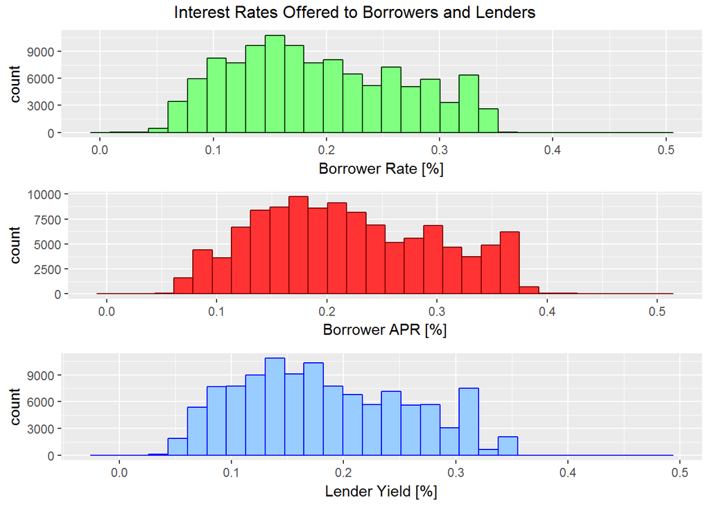

> The above histograms show the different interest rates offered to Prosper customers and are important to understand the range of interest rates the dataset contains. Borrower Rate is the rate offered to a person requesting a loan for the principle amount only. Borrower APR is the rate offered including all applicable fees charged by the lending institution. Lender Yield is the return a person lending money can expect if the loan is paid back fully by the loan applicant. I chose to work with Borrower APR as it is the most complete picture of the actual interest rate being charged to a loan applicant.

### Plot 2

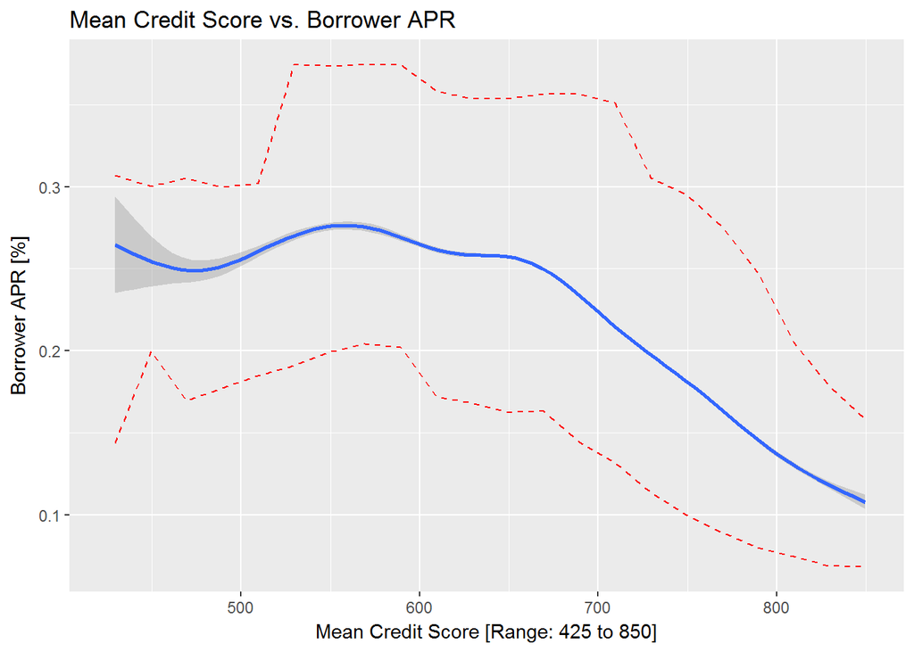

> This plot demonstrates the trend in the data when Mean Credit Score is plotted against Borrower APR. As credit score goes up (a person is less of a credit risk) the APR offered by Prosper goes down meaning the applicant is being offered a loan at a better rate. Because the data was somewhat noisy (the relationship is a general trend, it does not apply to everyone) I included 10% and 90% quartile lines as well, represented by the dotted red lines, so that the spread of the data would be visible too.

## Plot 3

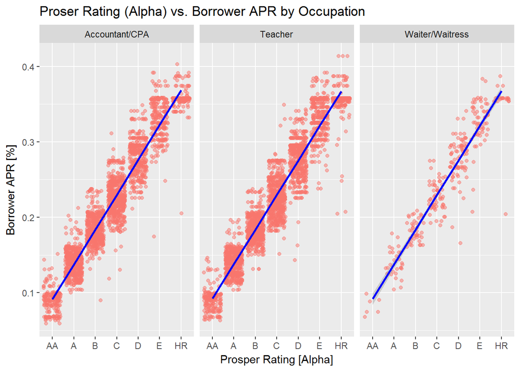

## Reflection

> The Prosper Loans dataset examined in this analysis contains 113,937 observations across 23 variables. My first step was to find which variables I wanted to examine in more detail. Beginning with the univariate section I began to examine what data the variables contained, eventually deciding I wanted to look at which variables impacted the Borrower APR.

> I discovered that many of the variables contained within the dataset could be seen to correlate with Borrower APR. Although, I did find it surprising that the correlation was not as strong as I might have imagined in many cases. One of the points that I consider a success would be the strong correlation between Mean Credit Score and Borrower APR. This seemed to make sense to me as many of the other variables (credit card information and debt load to name two) are considered when assigning a credit score to a person. One of the main difficulties in working with this data was just the sheer breadth of it. I had to make some hard choices on what to use and what to cut out, and I think this was one of the weaknesses of my exploration.

> There are two areas that I would like to explore further. 1) The other occupations. There were a total of 68 in the dataset, too many to work with in an exploratory manner. I think exploring the others might reveal additional insights related to a possible correlation between occupation and interest rates. 2) The other variables contained in the full dataset, which has about 60 additional variables that were not examined in this exploration. I pulled out the ones that looked most interesting to me from the start. Now that I have had a chance to explore the data I would like to go back and see what I might have missed.

> In a big picture view, the most important discovery I made while completing this analysis is to try to minimize the effects of my preconceptions while working with a dataset. I had some ideas coming into the project about what information the data would have, and was surprised more than a few times while viewing the plots of how my preconceptions were wildly off. This circumstance is illustrated by my reluctance to work with the Occupation variable. I made an assumption that I knew what data it held, but when I actually started working with it I was surprised again and again by what I found.

> I’ve always believed that the data should speak for itself, and I learned in this project that it is important to let it do so.